# Tugas Pertemuan 6

## Library

```r
library(TSA)
library(dplyr)
library(ggplot2)
library(tseries) ## adf.test
library(MASS) ## boxcox
library(forecast)
library(lmtest)
```

## Load Data

Data yang digunakan merupakan data yang berasal dari SIASATI (Sistem Informasi Angkutan dan Saruna Transportasi Indonesia) yang berisi data jumlah penumpang pesawat berangkat dari bandara BPN.

```r
dt <- read.csv("D:\\IPB\\5\\MPDW\\data\\others\\dt_pt3.csv")
head(dt)
```

```
##      Tanggal Penumpang.Berangkat
## 1 2023-08-19                6222
## 2 2023-08-20                6758
## 3 2023-08-21                6542
## 4 2023-08-22                7400
## 5 2023-08-23                7196
## 6 2023-08-24                6663
```

### Preprocessing Data

```r
names(dt) <- c("tanggal","penumpang")
dt$tanggal <- as.Date(dt$tanggal, format = "%Y-%m-%d")
summary(dt)
```

```
##     tanggal             penumpang
##  Min.   :2023-08-19   Min.   :5450
##  1st Qu.:2023-09-16   1st Qu.:6229
##  Median :2023-10-15   Median :6754
##  Mean   :2023-10-15   Mean   :6782
##  3rd Qu.:2023-11-12   3rd Qu.:7300
##  Max.   :2023-12-11   Max.   :8761
```

## Data Keseluruhan

### Visualisasi Data

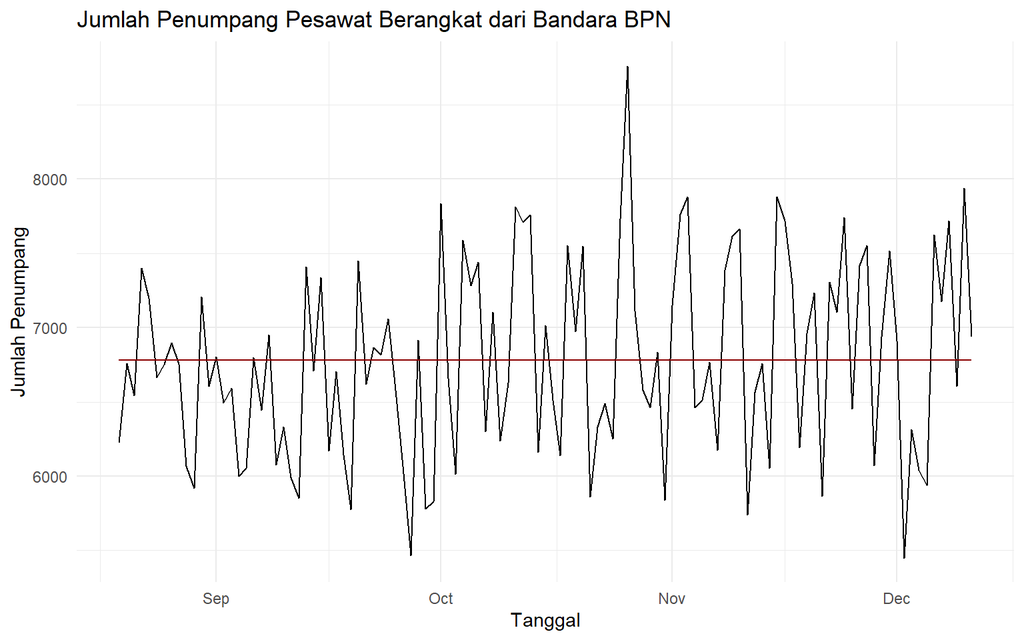

```r
ggplot(dt, aes(x = tanggal, y = penumpang)) +
  geom_line() +
  labs(title = "Jumlah Penumpang Pesawat Berangkat dari Bandara BPN",
       x = "Tanggal",
       y = "Jumlah Penumpang") +
  theme_minimal()+
  geom_line(aes(y = mean(penumpang)),col="darkred")
```

### ACF, PACF, EACF

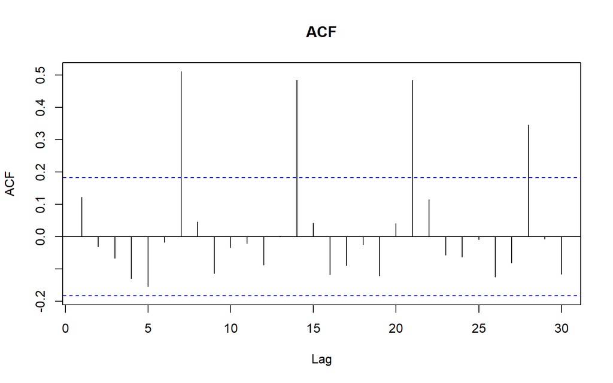

```r
acf(dt$penumpang, main = "ACF",lag.max=30)
```

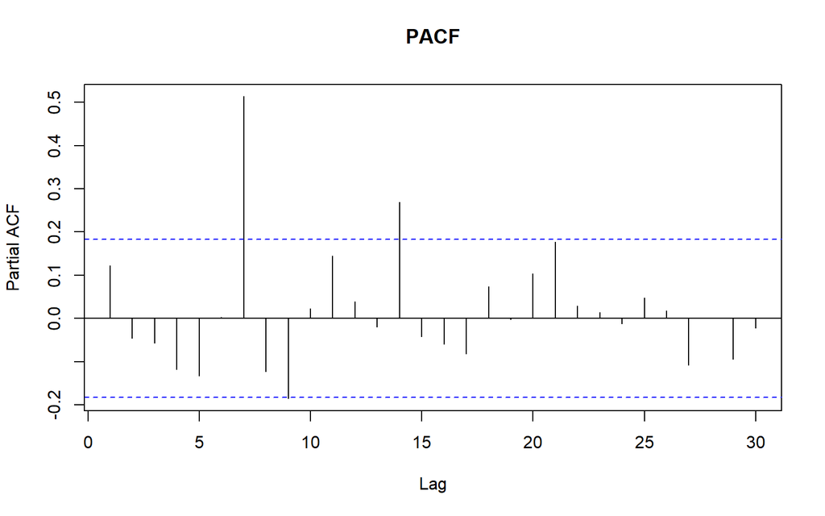

```r
pacf(dt$penumpang, main = "PACF",lag.max=30)
```

```r
eacf(dt$penumpang)
```

```
## AR/MA
##   0 1 2 3 4 5 6 7 8 9 10 11 12 13
## 0 o o o o o o x o o o o  o  o  x
## 1 x o o o o o x o o o o  o  o  x
## 2 x o o o o o x o o o o  o  o  x
## 3 x x o o o o x o o x o  o  o  x
## 4 x x o o o o x o o o o  o  o  x
## 5 o o o o x o x o o o o  o  o  x
## 6 o x x o x o x o o o o  o  o  x
## 7 x x o o o o x o o o o  o  o  o
```

Terlihat dari plot ACF dan PACF bahwa deret waktu memiliki pola yang cenderung seasonal. Kemungkinan besar pola musim yang ada adalah pola mingguan.

Dari hasil EACF kemungkinan model yang cocok adalah ARMA(2,1), ARMA(1,1), atau ARMA(1,2)

Melihat dari pola musiman maka kemungkinan model yang terbentuk adalah SARIMA(0,0,0)(2,0,0)[7]

### Cek Stasioner dalam Rataan

Untuk mengecek kestasioneran dari rataan kita dapat melihat secara eksploratif dan melakukan Uji Dickey-Fuller.

- $H_0$ : Deret waktu tidak stasioner dalam rataan
- $H_1$ : Deret waktu stasioner dalam rataan

```r
adf.test(dt$penumpang)
```

```
##
##  Augmented Dickey-Fuller Test
##
## data:  dt$penumpang
## Dickey-Fuller = -6.7858, Lag order = 4, p-value = 0.01
## alternative hypothesis: stationary
```

Hasil pengujian mendukung kecenderungan dari eksplorasi data sebelumnya yaitu data stasioner dalam rataan.

### Cek Stasioner dalam Ragam

Untuk mengecek kestasioneran dari ragam kita dapat menggunakan box-cox.

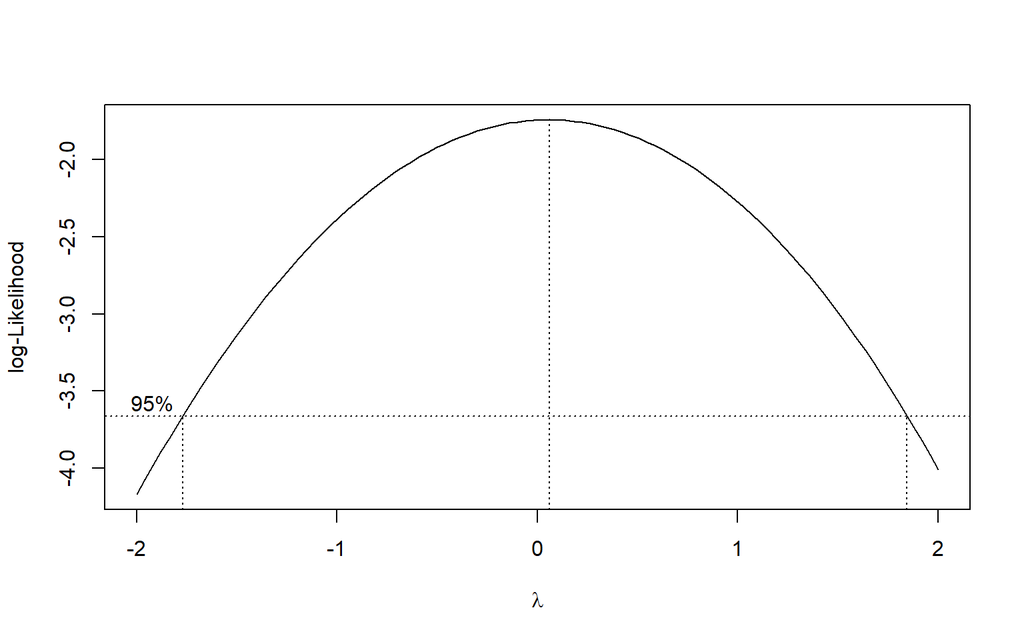

```r
index1 <- c(1:dim(dt)[1])
bc1 <- boxcox(penumpang~index1, data = dt)
```

```r
lambda1 <- bc1$x[which.max(bc1$y)]
lambda1
```

```
## [1] 0.06060606
```

```r
bc1$x[bc1$y > max(bc1$y) - 1/2 * qchisq(0.95,1)] %>% min()
```

```
## [1] -1.757576
```

```r
bc1$x[bc1$y > max(bc1$y) - 1/2 * qchisq(0.95,1)] %>% max()
```

```
## [1] 1.838384
```

Terlihat selang kepercayaan boxcox yaitu **-1.76** hingga **1.84** mengandung nilai 1. Yang berarti ragam dari data stasioner.

## Pemodelan ARIMA dan SARIMA

```r
dt.ts <- ts(dt$penumpang)
fit.auto <- auto.arima(dt.ts)
fit.auto
```

```
## Series: dt.ts
## ARIMA(5,1,1)
##
## Coefficients:
##           ar1      ar2      ar3      ar4      ar5      ma1
##       -0.0063  -0.1345  -0.1277  -0.1824  -0.2401  -0.9021
## s.e.   0.1008   0.0960   0.0947   0.0946   0.0985   0.0577
##
## sigma^2 = 414562:  log likelihood = -897.45
## AIC=1808.91   AICc=1809.96   BIC=1828.06
```

### ARMA(1,1)

```r
fit.arma11 <- arima(dt.ts, order = c(1,0,1))
fit.arma11
```

```
##
## Call:
## arima(x = dt.ts, order = c(1, 0, 1))
##
## Coefficients:
##           ar1     ma1  intercept
##       -0.7391  0.8531  6780.1460
## s.e.   0.1501  0.1130    64.2801
##
## sigma^2 estimated as 418666:  log likelihood = -907.56,  aic = 1821.11
```

```r
coeftest(fit.arma11)
```

```
##
## z test of coefficients:
##
##             Estimate Std. Error  z value  Pr(>|z|)
## ar1         -0.73909    0.15012  -4.9232 8.515e-07 ***
## ma1          0.85311    0.11305   7.5464 4.476e-14 ***
## intercept 6780.14601   64.28010 105.4781 < 2.2e-16 ***
## ---
## Signif. codes:  0 '***' 0.001 '**' 0.01 '*' 0.05 '.' 0.1 ' ' 1
```

### ARMA(2,1)

```r
fit.arma21 <- arima(dt.ts, order = c(2,0,1))
fit.arma21
```

```
##
## Call:
## arima(x = dt.ts, order = c(2, 0, 1))
##
## Coefficients:
##          ar1      ar2      ma1  intercept
##       0.7036  -0.1487  -0.5776  6779.5168
## s.e.  0.2974   0.0941   0.2878    57.5992
##
## sigma^2 estimated as 419793:  log likelihood = -907.68,  aic = 1823.36
```

```r
coeftest(fit.arma21)
```

```
##
## z test of coefficients:
##
##             Estimate Std. Error  z value Pr(>|z|)
## ar1          0.70362    0.29736   2.3662  0.01797 *
## ar2         -0.14873    0.09410  -1.5806  0.11398
## ma1         -0.57756    0.28782  -2.0067  0.04478 *
## intercept 6779.51678   57.59921 117.7016  < 2e-16 ***
## ---
## Signif. codes:  0 '***' 0.001 '**' 0.01 '*' 0.05 '.' 0.1 ' ' 1
```

### ARMA (1,2)

```r
fit.arma12 <- arima(dt.ts, order = c(1,0,2))
fit.arma12
```

```
##
## Call:
## arima(x = dt.ts, order = c(1, 0, 2))
##
## Coefficients:
##          ar1      ma1      ma2  intercept
##       0.5550  -0.4400  -0.1246  6779.9414
## s.e.  0.3742   0.3748   0.0883    59.4146
##
## sigma^2 estimated as 421224:  log likelihood = -907.87,  aic = 1823.74
```

```r
coeftest(fit.arma12)
```

```
##
## z test of coefficients:
##
##              Estimate  Std. Error  z value Pr(>|z|)
## ar1          0.555009    0.374166   1.4833   0.1380
## ma1         -0.440002    0.374805  -1.1739   0.2404
## ma2         -0.124623    0.088251  -1.4121   0.1579
## intercept 6779.941418   59.414587 114.1124   <2e-16 ***
## ---
## Signif. codes:  0 '***' 0.001 '**' 0.01 '*' 0.05 '.' 0.1 ' ' 1
```

### SARIMA(0,0,0)(2,0,0)[7]

```r
fit.sarima <- Arima(dt.ts, order = c(0,0,0), seasonal = list(order = c(2,0,0), period = 7))
fit.sarima
```

```
## Series: dt.ts
## ARIMA(0,0,0)(2,0,0)[7] with non-zero mean
##
## Coefficients:
##         sar1    sar2       mean
##       0.3373  0.3324  6791.9528
## s.e.  0.0908  0.0945   126.5011
##
## sigma^2 = 281556:  log likelihood = -885.02
## AIC=1778.05   AICc=1778.41   BIC=1789.03
```

```r
coeftest(fit.sarima)
```

```
##
## z test of coefficients:
##
##             Estimate Std. Error z value  Pr(>|z|)
## sar1      3.3730e-01 9.0759e-02  3.7164 0.0002021 ***
## sar2      3.3243e-01 9.4465e-02  3.5191 0.0004330 ***
## intercept 6.7920e+03 1.2650e+02 53.6908 < 2.2e-16 ***
## ---
## Signif. codes:  0 '***' 0.001 '**' 0.01 '*' 0.05 '.' 0.1 ' ' 1
```

### Pemilihan Model Terbaik

```r
list.model <- c("ARMA(1,1)","ARMA(2,1)","ARMA(1,2)","SARIMA(0,0,0)(2,0,0)[7]")
list.aic <- c(fit.arma11$aic,fit.arma21$aic,fit.arma12$aic,fit.sarima$aic)
list.bic <- c(fit.arma11$bic,fit.arma21$bic,fit.arma12$bic,fit.sarima$bic)

data.frame(list.model,list.aic,list.bic)
```

```
##                list.model list.aic list.bic
## 1               ARMA(1,1) 1821.111 1789.029
## 2               ARMA(2,1) 1823.359 1789.029
## 3               ARMA(1,2) 1823.738 1789.029
## 4 SARIMA(0,0,0)(2,0,0)[7] 1778.049 1789.029
```

### Overfitting

```r
fit.sarima2 <- Arima(dt.ts, order = c(1,0,0), seasonal = list(order = c(2,0,0), period = 7))
fit.sarima2
```

```
## Series: dt.ts
## ARIMA(1,0,0)(2,0,0)[7] with non-zero mean
##
## Coefficients:
##          ar1    sar1    sar2       mean
##       0.2078  0.3521  0.3379  6791.2918
## s.e.  0.0917  0.0898  0.0933   163.8158
##
## sigma^2 = 271129:  log likelihood = -882.52
## AIC=1775.04   AICc=1775.59   BIC=1788.77
```

```r
coeftest(fit.sarima2)
```

```
##
## z test of coefficients:
##
##             Estimate Std. Error z value  Pr(>|z|)
## ar1       2.0777e-01 9.1739e-02  2.2648 0.0235238 *
## sar1      3.5210e-01 8.9850e-02  3.9188   8.9e-05 ***
## sar2      3.3787e-01 9.3337e-02  3.6199 0.0002947 ***
## intercept 6.7913e+03 1.6382e+02 41.4569 < 2.2e-16 ***
## ---
## Signif. codes:  0 '***' 0.001 '**' 0.01 '*' 0.05 '.' 0.1 ' ' 1
```

```r
fit.sarima3 <- Arima(dt.ts, order = c(0,0,1), seasonal = list(order = c(2,0,0), period = 7))
fit.sarima3
```

```
## Series: dt.ts
## ARIMA(0,0,1)(2,0,0)[7] with non-zero mean
##
## Coefficients:
##          ma1    sar1    sar2       mean
##       0.1706  0.3464  0.3364  6790.9115
## s.e.  0.0835  0.0899  0.0935   149.9829
##
## sigma^2 = 273657:  log likelihood = -882.99
## AIC=1775.98   AICc=1776.53   BIC=1789.71
```

```r
coeftest(fit.sarima3)
```

```
##
## z test of coefficients:
##
##             Estimate Std. Error z value  Pr(>|z|)
## ma1       1.7057e-01 8.3461e-02  2.0437 0.0409825 *
## sar1      3.4644e-01 8.9900e-02  3.8536 0.0001164 ***
## sar2      3.3643e-01 9.3501e-02  3.5982 0.0003205 ***
## intercept 6.7909e+03 1.4998e+02 45.2779 < 2.2e-16 ***
## ---
## Signif. codes:  0 '***' 0.001 '**' 0.01 '*' 0.05 '.' 0.1 ' ' 1
```

```r
fit.sarima4 <- Arima(dt.ts, order = c(0,0,0), seasonal = list(order = c(3,0,0), period = 7))
fit.sarima4
```

```
## Series: dt.ts
## ARIMA(0,0,0)(3,0,0)[7] with non-zero mean
##
## Coefficients:
##         sar1    sar2    sar3       mean
##       0.2578  0.1989  0.3013  6784.2697
## s.e.  0.0917  0.1016  0.0967   144.3635
##
## sigma^2 = 258901:  log likelihood = -880.53
## AIC=1771.06   AICc=1771.61   BIC=1784.79
```

```r
coeftest(fit.sarima4)
```

```
##
## z test of coefficients:
##
##             Estimate Std. Error z value  Pr(>|z|)
## sar1      2.5782e-01 9.1692e-02  2.8118  0.004927 **
## sar2      1.9893e-01 1.0159e-01  1.9580  0.050224 .
## sar3      3.0131e-01 9.6687e-02  3.1163  0.001831 **
## intercept 6.7843e+03 1.4436e+02 46.9944 < 2.2e-16 ***
## ---
## Signif. codes:  0 '***' 0.001 '**' 0.01 '*' 0.05 '.' 0.1 ' ' 1
```

```r
fit.sarima5 <- Arima(dt.ts, order = c(0,0,0), seasonal = list(order = c(2,0,1), period = 7))
fit.sarima5
```

```
## Series: dt.ts
## ARIMA(0,0,0)(2,0,1)[7] with non-zero mean
##
## Coefficients:
##         sar1    sar2     sma1      mean
##       0.8363  0.0908  -0.6139  6779.464
## s.e.  0.1828  0.1456   0.1663   157.040
##
## sigma^2 = 261765:  log likelihood = -881.18
## AIC=1772.36   AICc=1772.91   BIC=1786.08
```

```r
coeftest(fit.sarima5)
```

```
##
## z test of coefficients:
##
##              Estimate  Std. Error z value  Pr(>|z|)
## sar1         0.836319    0.182783  4.5755 4.752e-06 ***
## sar2         0.090846    0.145554  0.6241 0.5325370
## sma1        -0.613907    0.166310 -3.6913 0.0002231 ***
## intercept 6779.463833  157.039995 43.1703 < 2.2e-16 ***
## ---
## Signif. codes:  0 '***' 0.001 '**' 0.01 '*' 0.05 '.' 0.1 ' ' 1
```

### Perbandingan Overfitting

```r
list.model2 <- c("SARIMA(0,0,0)(2,0,0)[7]","SARIMA(1,0,0)(2,0,0)[7]","SARIMA(0,0,1)(2,0,0)[7]","SARIMA(0,0,0)(3,0,0)[7]","SARIMA(0,0,0)(2,0,1)[7]")
list.aic2 <- c(fit.sarima$aic,fit.sarima2$aic,fit.sarima3$aic,fit.sarima4$aic,fit.sarima5$aic)
list.bic2 <- c(fit.sarima$bic,fit.sarima2$bic,fit.sarima3$bic,fit.sarima4$bic,fit.sarima5$bic)

data.frame(list.model2,list.aic2,list.bic2)
```

```
##               list.model2 list.aic2 list.bic2
## 1 SARIMA(0,0,0)(2,0,0)[7]  1778.049  1789.029
## 2 SARIMA(1,0,0)(2,0,0)[7]  1775.043  1788.767
## 3 SARIMA(0,0,1)(2,0,0)[7]  1775.981  1789.706
## 4 SARIMA(0,0,0)(3,0,0)[7]  1771.061  1784.786
## 5 SARIMA(0,0,0)(2,0,1)[7]  1772.358  1786.083
```

SARIMA(0,0,0)(3,0,0)[7] merupakan model terbaik karena memiliki nilai AIC dan BIC yang paling kecil.

## Diagnosa Model

### Modelling

```r
fit.sarima4
```

```
## Series: dt.ts
## ARIMA(0,0,0)(3,0,0)[7] with non-zero mean
##
## Coefficients:
##         sar1    sar2    sar3       mean
##       0.2578  0.1989  0.3013  6784.2697
## s.e.  0.0917  0.1016  0.0967   144.3635
##
## sigma^2 = 258901:  log likelihood = -880.53
## AIC=1771.06   AICc=1771.61   BIC=1784.79
```

### Eksplorasi Sisaan

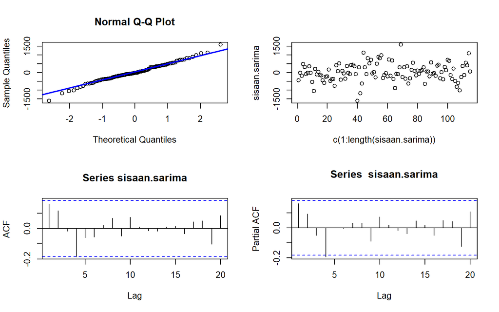

```r
sisaan.sarima <- fit.sarima4$residuals
par(mfrow=c(2,2))
qqnorm(sisaan.sarima)
qqline(sisaan.sarima, col = "blue", lwd = 2)
plot(c(1:length(sisaan.sarima)),sisaan.sarima)
acf(sisaan.sarima)
pacf(sisaan.sarima)
```

```r
par(mfrow = c(1,1))
```

### Uji Formal

```r
ks.test(sisaan.sarima,"pnorm")
```

```
##
##  Asymptotic one-sample Kolmogorov-Smirnov test
##
## data:  sisaan.sarima
## D = 0.53043, p-value < 2.2e-16
## alternative hypothesis: two-sided
```

tolak H0 sehingga sisaan tidak normal

```r
#2) Sisaan saling bebas/tidak ada autokorelasi
Box.test(sisaan.sarima, type = "Ljung")
```

```
##
##  Box-Ljung test
##
## data:  sisaan.sarima
## X-squared = 3.1127, df = 1, p-value = 0.07768
```

```r
#tak tolak H0 > sisaan saling bebas
```

```r
#3) Sisaan homogen
Box.test((sisaan.sarima)^2, type = "Ljung")
```

```
##
##  Box-Ljung test
##
## data:  (sisaan.sarima)^2
## X-squared = 0.10793, df = 1, p-value = 0.7425
```

```r
#tak tolak H0 > sisaan homogen
```

Ragam Homogen

```r
#4) Nilai tengah sisaan sama dengan nol
t.test(sisaan.sarima, mu = 0, conf.level = 0.95)
```

```
##
##  One Sample t-test
##
## data:  sisaan.sarima
## t = 0.28305, df = 114, p-value = 0.7777
## alternative hypothesis: true mean is not equal to 0
## 95 percent confidence interval:
##  -79.46898 105.96412
## sample estimates:
## mean of x
##  13.24757
```

```r
#tak tolak h0 > nilai tengah sisaan sama dengan 0
```

Nilai tengah sisaan sama dengan 0

## Kesimpulan

Model terbaik adalah model SAR (3,0,0)[7] namun tidak memenuhi asumsi sisaan menyebar normal.